# Prediction Assignment Writeup

Diego Ignacio Rivera Lisboa

6/21/2020

## Summary

For this assignment, using the provided Data Set, after reducing the number of features through both correlation and the rfe function, we train a random forest model with 20 features, arriving a model that shows 0.95 accuracy on the test set. In terms of cross-validarion, both the rfe and the “rf” method in the caret package already involve their own forms of cross-validation. Besides this, the training data set was split unto another training and test set to properly test out of sample error.

## Characteristics of the Data Set

The provided data set (Velloso et al, 2013) comes from human activity recognition research, in particular, the effort to discriminate between different types of activities. As such, 6 subjects were asked to do 10 repetitions of Dumbbell Biceps Curls in 5 different ways, one correct, and the other four incorrect in different ways.

The data was produced with a set of different sensors ubicated on the body of the subjects and the dumbells.

## Data Processing

The data already comes split between a training and test data set, which is comprised of only 20 observations. We will disregard the test data set, leaving it as a sort of validation set in the Quiz (which will not be reported here). And so, we will split the training set into a training and test portion in a 4/5 proportion to be able to test out-of-sample error.

In general terms, the training data set will be comprised of 15699 observations and the testing set of 3923 observations. In terms of overall sampling, the training data set is composed of:

```
##
##    A    B    C    D    E
## 4464 3038 2738 2573 2886
```

And in terms of subjects:

```
##
##   adelmo carlitos  charles   eurico   jeremy    pedro
##     3117     2479     2846     2444     2722     2091
```

A coursory inspection of a lot of variables show that they posses a large number of NA values. I will suppose that this NA values correspond to having no measure to record in the sensors, and so will be transformed to 0.

Then, 160 variables are far too much variables to process comfortably and might lead to overfitting. As such, we will aim to reduce them to a more manageable number.

First, we can disregard both the time data, as it would make the model too complex, the data about the users, as it might make the model more prone to overfitting.

After that, we create a correlation matrix to reduce the number of variables to those that provide the most information with a criterion of those that have an r=0.75 as ones that can be safely disregarded.

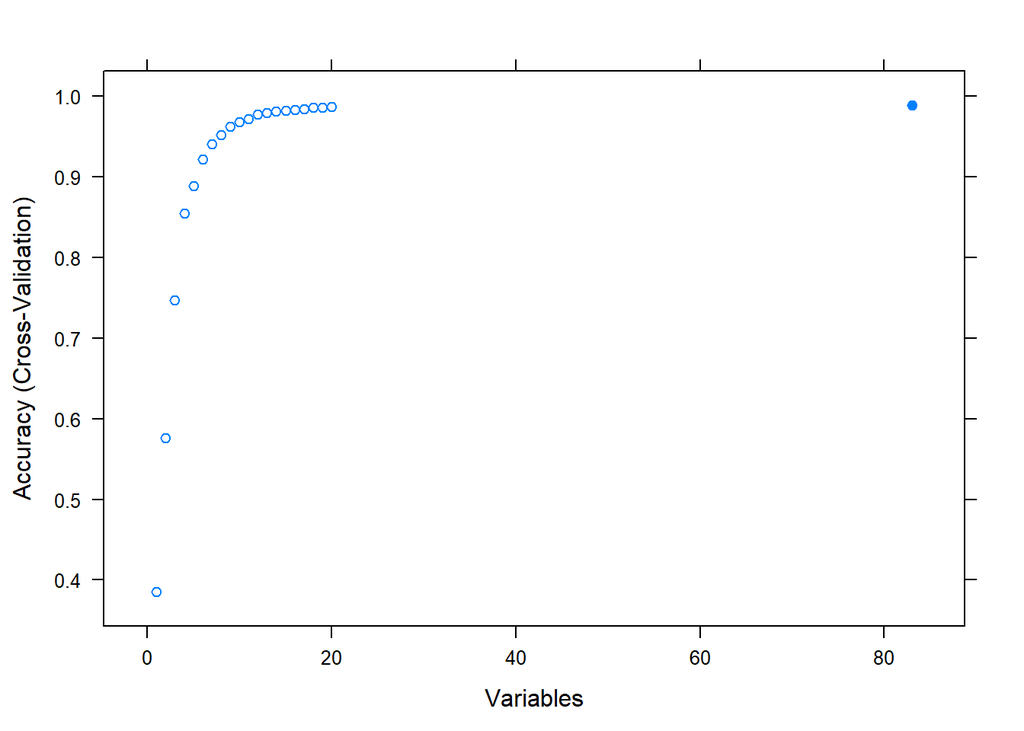

## Training Model

A random forest approach was selected, as this was a task to differenciate different factors that might not necessarily show a linear relationship, as such a decision tree would likely be more effective. Forests were chosen due to the fact that bootstrapping and crossvalidation come baked into the assumptions of the model. Again, due to the computationally demanding nature of the task, we will load it once again.

```
## Confusion Matrix and Statistics
##
##           Reference
## Prediction    A    B    C    D    E
##          A 4464    0    0    0    0
##          B    0 3037    0    0    0
##          C    0    1 2738    1    0
##          D    0    0    0 2572    1
##          E    0    0    0    0 2885
##
## Overall Statistics
##
##                Accuracy : 0.9998
##                  95% CI : (0.9994, 1)
##     No Information Rate : 0.2843
##     P-Value [Acc > NIR] : < 2.2e-16
##
##                   Kappa : 0.9998
##
##  Mcnemar's Test P-Value : NA
##
## Statistics by Class:
##
##                      Class: A Class: B Class: C Class: D Class: E
## Sensitivity            1.0000   0.9997   1.0000   0.9996   0.9997
## Specificity            1.0000   1.0000   0.9998   0.9999   1.0000
## Pos Pred Value         1.0000   1.0000   0.9993   0.9996   1.0000
## Neg Pred Value         1.0000   0.9999   1.0000   0.9999   0.9999
## Prevalence             0.2843   0.1935   0.1744   0.1639   0.1838
## Detection Rate         0.2843   0.1935   0.1744   0.1638   0.1838
## Detection Prevalence   0.2843   0.1935   0.1745   0.1639   0.1838
## Balanced Accuracy      1.0000   0.9998   0.9999   0.9998   0.9998
```

## Results

```
## Confusion Matrix and Statistics
##
##           Reference
## Prediction    A    B    C    D    E
##          A 1099   26    3    3    0
##          B    3  699   20    3    4
##          C    2   18  640   33    9
##          D   10   14   13  604    4
##          E    2    2    8    0  704
##
## Overall Statistics
##
##                Accuracy : 0.9549
##                  95% CI : (0.9479, 0.9612)
##     No Information Rate : 0.2845
##     P-Value [Acc > NIR] : < 2.2e-16
##
##                   Kappa : 0.9429
##
##  Mcnemar's Test P-Value : 2.31e-06
##
## Statistics by Class:
##
##                      Class: A Class: B Class: C Class: D Class: E
## Sensitivity            0.9848   0.9209   0.9357   0.9393   0.9764
## Specificity            0.9886   0.9905   0.9809   0.9875   0.9963
## Pos Pred Value         0.9717   0.9588   0.9117   0.9364   0.9832
## Neg Pred Value         0.9939   0.9812   0.9863   0.9881   0.9947
## Prevalence             0.2845   0.1935   0.1744   0.1639   0.1838
## Detection Rate         0.2801   0.1782   0.1631   0.1540   0.1795
## Detection Prevalence   0.2883   0.1858   0.1789   0.1644   0.1825
## Balanced Accuracy      0.9867   0.9557   0.9583   0.9634   0.9863
```

```
## [1] 0.0521 0.0388
```

## References

```r
library(caret)
library(randomForest)
library(dplyr)

#The code to obtain the data set
trainURL<-"https://d396qusza40orc.cloudfront.net/predmachlearn/pml-training.csv"
testURL<-"https://d396qusza40orc.cloudfront.net/predmachlearn/pml-testing.csv"
download.file(trainURL, destfile="./pml-training.csv", method="curl")
download.file(testURL, destfile="./pml-testing.csv", method="curl")

#Splitting
set.seed(32678)
set1<-read.csv("pml-training.csv", header=T, na.strings=c("","NA"), stringsAsFactors = FALSE)
validation<-read.csv("pml-testing.csv", header=T, na.strings=c("","NA"), stringsAsFactors = FALSE)
inTrain<-createDataPartition(y=set1$classe, p=0.8, list=FALSE)
training<-set1[inTrain,]
testing<-set1[-inTrain,]

#Exploratory Analysis

table(training$classe)
table(training$user_name)

#Transformation of the Training Data Set
trainDF<-training[,-(1:7)]
for(i in 1:153){
  trainDF[is.na(trainDF[,i]), i]<-0}
trainDF<-trainDF %>% mutate_if(is.character, as.factor)
trainy<-trainDF[,153]
traincor<-trainDF[,1:152]
traincor<-traincor %>% mutate_if(is.factor, as.numeric)

#Transformation of the Test Data Set
testDF<-testing[,-(1:7)]
for(i in 1:153){
  testDF[is.na(testDF[,i]), i]<-0}
testDF<-testDF %>% mutate_if(is.character, as.factor)
testy<-testDF[,153]
testcor<-testDF[,1:152]
testcor<-testcor %>% mutate_if(is.factor, as.numeric)

#Transformation of the Validation Data Set

valDF<-validation[,-(1:7)]
for(i in 1:153){
  valDF[is.na(testDF[,i]), i]<-0}
valDF<-valDF %>% mutate_if(is.character, as.factor)
valcor<-valDF[,1:152]
valcor<-valcor %>% mutate_if(is.factor, as.numeric)

#First feature reduction of the Training data set
correlationMatrix <- cor(traincor)
highlyCorrelated <- findCorrelation(correlationMatrix, cutoff=0.75)
trainprun<-traincor[,-highlyCorrelated]

##Second feature reduction of the Training data set
control <- rfeControl(functions=rfFuncs, method="cv", number=10)
# run the RFE algorithm
traintree<-data.frame(trainprun, y=trainy)
results <- rfe(traintree[,1:83], traintree[,84], sizes=c(1:20), rfeControl=control)

#Training of the two different models
#Random Forest
trainforest<-trainprun[,predictors(results)[1:20]]
trainForest<-data.frame(trainforest, y=trainy)
forestfit<-train(y~., method="rf", data=trainForest)
trainp<-predict(forestfit, training)

#Testing the models in the training data set
confusionMatrix(trainp, trainy)

#Test set
test<-predict(forestfit, testing)
confusionMatrix(test, testy)

#The code for loading and saving the model

save(forestfit, file = "forestfit.RData")
save(results, file="results.RData")

load("forestfit.RData")
load("results.RData")
```